# Overview

```python
import matplotlib as mpl
import matplotlib.pyplot as plt
#from ipywidgets import interact, widgets

mpl.rcParams['axes.spines.right'] = False
mpl.rcParams['axes.spines.top'] = False

import altair as alt
import arviz as az
import numpyro
import pandas as pd
from jax import grad, jit
from jax import numpy as jnp
from jax import random, vmap
from numpyro import distributions as dist
from numpyro.infer import MCMC, NUTS

from lqg import LQG, Actor, Dynamics, System, xcorr
```

import matplotlib as mpl import matplotlib.pyplot as plt #from ipywidgets import interact, widgets mpl.rcParams['axes.spines.right'] = False mpl.rcParams['axes.spines.top'] = False import altair as alt import arviz as az import numpyro import pandas as pd from jax import grad, jit from jax import numpy as jnp from jax import random, vmap from numpyro import distributions as dist from numpyro.infer import MCMC, NUTS from lqg import LQG, Actor, Dynamics, System, xcorr

```python
# We have to use DataFrames that a larger than recommended -> turn off the error
alt.data_transformers.disable_max_rows()
```

# We have to use DataFrames that a larger than recommended -> turn off the error alt.data_transformers.disable_max_rows()

```
DataTransformerRegistry.enable('default')
```

## Quick intro to jax

### 1. NumPy-like API: `jax.numpy`

JAX is a library that enables transformations of array-manipulating programs written with a NumPy-like API. You can think of JAX as differentiable NumPy that runs on accelerators. Many NumPy programs would run just as well in JAX if you substitute np for jnp.

```python
a = jnp.array([[1., 2.],
               [3., 4.]])
```

a = jnp.array([[1., 2.], [3., 4.]])

```python
key = random.PRNGKey(1)
b = random.normal(key, shape=(2, 3))

a @ b
```

key = random.PRNGKey(1) b = random.normal(key, shape=(2, 3)) a @ b

```
Array([[ 1.6896877, -0.6240323,  1.5889112],
       [ 4.3366823, -2.2179935,  4.184889 ]], dtype=float32)
```

### 2. Automatic differentiation: `grad`

You can think of `jax.grad` by analogy to the $\nabla$ operator from vector calculus. Given a function $f(x)$, $\nabla f$ represents the function that computes $f$’s gradient, i.e.

$$ (\nabla f)(x)_i = \frac{\partial f}{\partial x_i} (x). $$

Analogously, `jax.grad(f)` is the function that computes the gradient, so `jax.grad(f)(x)` is the gradient of `f` at `x`.

```python
def f(x):
    return jnp.sin(x)

grad(f)(jnp.pi)
```

def f(x): return jnp.sin(x) grad(f)(jnp.pi)

```
Array(-1., dtype=float32, weak_type=True)
```

### 3. Easy vectorization: `vmap`

In JAX, the `jax.vmap` transformation is designed to generate a vectorized implementation of a function automatically.

```python
x = jnp.linspace(0, 2 * jnp.pi)
```

x = jnp.linspace(0, 2 * jnp.pi)

```python
plt.plot(x, f(x))
plt.plot(x, vmap(grad(f))(x))
```

plt.plot(x, f(x)) plt.plot(x, vmap(grad(f))(x))

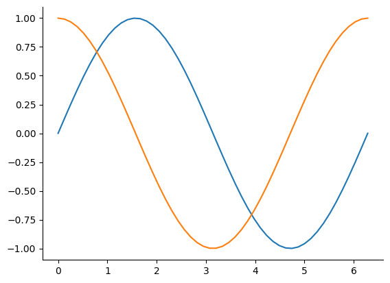

### 4. Compilation: `jit`

You can use the XLA (accelerated linear algebra) compiler to compile your functions with `jax.jit`.

```python
def f(x):
    return x * x + x * 2.0

x = jnp.ones((5000, 5000))
```

def f(x): return x * x + x * 2.0 x = jnp.ones((5000, 5000))

```python
%timeit f(x)
```

%timeit f(x)

```
63 ms ± 1.7 ms per loop (mean ± std. dev. of 7 runs, 10 loops each)
```

```python
jit_f = jit(f)
%timeit jit_f(x)
```

jit_f = jit(f) %timeit jit_f(x)

```
22.8 ms ± 1.91 ms per loop (mean ± std. dev. of 7 runs, 10 loops each)
```

## Putting perception into action: Inverse optimal control for continuous psychophysics

### Modeling a tracking task with LQG control

The LQG control problem is defined by a linear-Gaussian stochastic dynamical system $$ \mathbf x_{t+1} = A \mathbf x_t + B \mathbf u_t + V \mathbf \epsilon_t, \; \mathbf\epsilon_t \sim \mathcal{N}(0, I), $$

a linear-Gaussian observation model $$ \mathbf y_t = C \mathbf x_t + W \mathbf \eta_t, \; \mathbf\eta_t \sim \mathcal{N}(0, I), $$

and a quadratic cost function

$$ J = \sum_t \mathbf x_t^T Q \mathbf x_t + \mathbf u_t^T R \mathbf u_t. $$

We assume that the actor solves the linear-quadratic Gaussian problem, i.e. computes the Kalman filter $K$ and the LQR control law $L$, which are the optimal solution under the quadratic cost function

$$ J(u_{1:T}) = \sum_{t=1}^T \mathbf x_t^T Q \mathbf x_t + \mathbf u_t^T R \mathbf u_t. $$

We start by defining the matrices $A, B, C, V, W, Q, R$ as `jax.numpy.array`s. according to our simple model of the continuous psychophysics tracking task:

$$ A = \begin{bmatrix} 1 & 0 \\ 0 & 1 \end{bmatrix}, \; B = \begin{bmatrix} 0 \\ dt \end{bmatrix}, \; C = \begin{bmatrix} 1 & 0 \\ 0 & 1 \end{bmatrix}, \\ V = \begin{bmatrix} \sigma_\text{rw} & 0 \\ 0 & \sigma_\text{act} \end{bmatrix}, \; W = \begin{bmatrix} \sigma & 0 \\ 0 & \sigma_\text{cursor} \end{bmatrix}, \\ Q = \begin{bmatrix} 1 & -1 \\ -1 & 1 \end{bmatrix}, \; R = \begin{bmatrix} c \end{bmatrix}. $$

```python
action_variability = 0.5
sigma_target = 6.
sigma_cursor = 1.
action_cost = .05

dt = 1. / 60.

# dynamical system
A = jnp.eye(2)
B = jnp.array([[0.],
              [dt]])

# noise
V = jnp.diag(jnp.array([1., action_variability]))

# observation model
C = jnp.eye(2)
W = jnp.diag(jnp.array([sigma_target, sigma_cursor]))

# cost function
Q = jnp.array([[1., -1.],
              [-1., 1]])

R = jnp.eye(1) * action_cost

T = 500
model = LQG(A, B, C, V, W, Q, R, T=T)
```

action_variability = 0.5 sigma_target = 6. sigma_cursor = 1. action_cost = .05 dt = 1. / 60. # dynamical system A = jnp.eye(2) B = jnp.array([[0.], [dt]]) # noise V = jnp.diag(jnp.array([1., action_variability])) # observation model C = jnp.eye(2) W = jnp.diag(jnp.array([sigma_target, sigma_cursor])) # cost function Q = jnp.array([[1., -1.], [-1., 1]]) R = jnp.eye(1) * action_cost T = 500 model = LQG(A, B, C, V, W, Q, R, T=T)

The `System` class, which `LQG` extends, can be pretty-printed. When calling `display(model)`, the matrices of your model will be displayed as $\LaTeX$ math formula. The same happens when the output of a cell is printed. Standard (i.e., not so pretty) printing can still be achieved through `print(model)`.

```python
model  # equivalent to `display(model)`
```

model # equivalent to `display(model)`

\begin{align*} \text{Dynamics:} &&A = \begin{bmatrix} 1. & 0.\\ 0. & 1.\\\end{bmatrix} &&B = \begin{bmatrix} 0.\\ 0.0167\\\end{bmatrix} &&F = \begin{bmatrix} 1. & 0.\\ 0. & 1.\\\end{bmatrix} &&V = \begin{bmatrix} 1. & 0.\\ 0. & 0.5\\\end{bmatrix} &&W = \begin{bmatrix} 6. & 0.\\ 0. & 1.\\\end{bmatrix}\\\text{Actor:} &&A = \begin{bmatrix} 1. & 0.\\ 0. & 1.\\\end{bmatrix} &&B = \begin{bmatrix} 0.\\ 0.0167\\\end{bmatrix} &&F = \begin{bmatrix} 1. & 0.\\ 0. & 1.\\\end{bmatrix} &&V = \begin{bmatrix} 1. & 0.\\ 0. & 0.5\\\end{bmatrix} &&W = \begin{bmatrix} 6. & 0.\\ 0. & 1.\\\end{bmatrix} &&Q = \begin{bmatrix} 1. & -1.\\ -1. & 1.\\\end{bmatrix} &&R = \begin{bmatrix} 0.05\\\end{bmatrix}\end{align*}

Let's simulate some tracking data by applying the Kalman filter and linear-quadratic regular. This is implemented in the method `simulate(rng_key, n, T)`. Since `jax` does not have a global random number generator state, we need to pass a `PRNGKey` object. `n` is the number of trials and `T` is the number of time steps.

```python
x = model.simulate(random.PRNGKey(0), n=100)

plt.plot(jnp.arange(T) * dt, x[0, :, 0], label="target")
plt.plot(jnp.arange(T) * dt, x[0, :, 1], label="cursor")
plt.legend()
plt.xlabel("Time [s]")
plt.ylabel("Position [arcmin]")
plt.show()
```

x = model.simulate(random.PRNGKey(0), n=100) plt.plot(jnp.arange(T) * dt, x[0, :, 0], label="target") plt.plot(jnp.arange(T) * dt, x[0, :, 1], label="cursor") plt.legend() plt.xlabel("Time [s]") plt.ylabel("Position [arcmin]") plt.show()

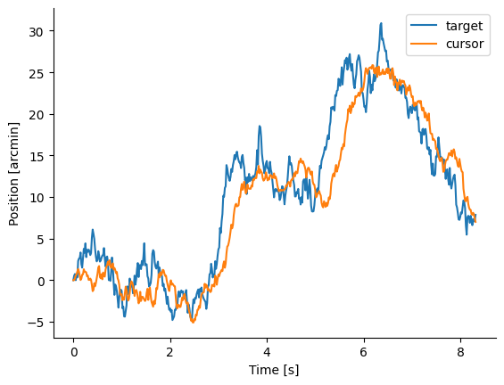

```python
x.shape
```

x.shape

```
(100, 500, 2)
```

### Cross-correlograms

```python
vels = jnp.diff(x, axis=1)
lags, correls = xcorr(vels[...,1], vels[...,0], maxlags=120)

plt.plot(lags, correls.mean(axis=0))
plt.xlabel("Lag [s]")
plt.ylabel("Cross-correlation")
```

vels = jnp.diff(x, axis=1) lags, correls = xcorr(vels[...,1], vels[...,0], maxlags=120) plt.plot(lags, correls.mean(axis=0)) plt.xlabel("Lag [s]") plt.ylabel("Cross-correlation")

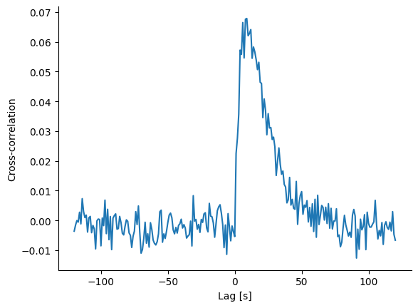

### Influence of model parameters

To look a the influence of the different model parameters, we define a class that inherits from the `LQG` base class and defines the matrices given the four parameters.

```python
class BoundedActor(LQG):
    def __init__(self,
               sigma_target,
               action_variability,
               action_cost,
               sigma_cursor):

        dt = 1. / 60.

        A = jnp.eye(2)
        B = jnp.array([[0.],
                      [dt]])

        V = jnp.diag(jnp.array([1., action_variability]))

        F = jnp.eye(2)
        W = jnp.diag(jnp.array([sigma_target, sigma_cursor]))


        Q = jnp.array([[1., -1.],
                      [-1., 1]])

        R = jnp.eye(1) * action_cost


        super().__init__(A=A, B=B, F=F, V=V, W=W, Q=Q, R=R, T=T)
```

class BoundedActor(LQG): def __init__(self, sigma_target, action_variability, action_cost, sigma_cursor): dt = 1. / 60. A = jnp.eye(2) B = jnp.array([[0.], [dt]]) V = jnp.diag(jnp.array([1., action_variability])) F = jnp.eye(2) W = jnp.diag(jnp.array([sigma_target, sigma_cursor])) Q = jnp.array([[1., -1.], [-1., 1]]) R = jnp.eye(1) * action_cost super().__init__(A=A, B=B, F=F, V=V, W=W, Q=Q, R=R, T=T)

We can now simulate data from the model given the four parameters. To do this efficiently, we `jit`-compile the simulation function.

Some observations:

- An increase in action costs leads to an increased lag and decreased maximum correlation.
- An increase in perceptual uncertainty about the target leads to decreased correlation and increased lag, too, but the shape of the curves changes differently compared to the effect of the behavioral cost.
- Action variability does not change the lag, but decreases correlation overall.
- Perceptual uncertainty about the cursor does not change the shape of the CCGs at all, but does increase the mean squared error between target and response.

```python
@jit  # jit-compile the simulation to speed up the data generation
def simulate_trajectories(sigma_target, action_cost, action_variability, sigma_cursor):
    model = BoundedActor(
        sigma_target=sigma_target,
        action_variability=action_variability,
        action_cost=action_cost,
        sigma_cursor=sigma_cursor,
    )

    x = model.simulate(random.PRNGKey(0), n=100)

    return x
```

@jit # jit-compile the simulation to speed up the data generation def simulate_trajectories(sigma_target, action_cost, action_variability, sigma_cursor): model = BoundedActor( sigma_target=sigma_target, action_variability=action_variability, action_cost=action_cost, sigma_cursor=sigma_cursor, ) x = model.simulate(random.PRNGKey(0), n=100) return x

```python
# Simulate data and store it in a DataFrame
data_trajectory = []
data_ccg = []

sigma_target_list = [1.0, 10.0, 100.0]
action_cost_list = [0.2, 1.0, 5.0]
action_variability_list = [0.25, 0.5, 1.0]
sigma_cursor_list = [1.0, 10.0, 100.0]

time_max = 500
time = jnp.arange(time_max) * dt

for sigma_target in sigma_target_list:
    for action_cost in action_cost_list:
        for action_variability in action_variability_list:
            for sigma_cursor in sigma_cursor_list:
                x = simulate_trajectories(
                    sigma_target, action_cost, action_variability, sigma_cursor
                )
                for i, step in enumerate(x[0]):
                    data_trajectory.append(
                        [
                            sigma_target,
                            action_cost,
                            action_variability,
                            sigma_cursor,
                            "target",
                            time[i].item(),
                            step[0].item(),
                        ]
                    )
                    data_trajectory.append(
                        [
                            sigma_target,
                            action_cost,
                            action_variability,
                            sigma_cursor,
                            "cursor",
                            time[i].item(),
                            step[1].item(),
                        ]
                    )

                vels = jnp.diff(x, axis=1)
                lags, correls = xcorr(vels[..., 1], vels[..., 0], maxlags=120)
                lags = lags / 60
                correls = correls.mean(axis=0)

                for lag, correl in zip(lags, correls):
                    data_ccg.append(
                        [
                            sigma_target,
                            action_cost,
                            action_variability,
                            sigma_cursor,
                            lag.item(),
                            correl.item(),
                        ]
                    )

df_trajectory = pd.DataFrame(
    data_trajectory,
    columns=[
        "sigma_target",
        "action_cost",
        "action_variability",
        "sigma_cursor",
        "value",
        "time",
        "position",
    ],
)
df_ccg = pd.DataFrame(
    data_ccg,
    columns=["sigma_target", "action_cost", "action_variability", "sigma_cursor", "lag", "correl"],
)
```

# Simulate data and store it in a DataFrame data_trajectory = [] data_ccg = [] sigma_target_list = [1.0, 10.0, 100.0] action_cost_list = [0.2, 1.0, 5.0] action_variability_list = [0.25, 0.5, 1.0] sigma_cursor_list = [1.0, 10.0, 100.0] time_max = 500 time = jnp.arange(time_max) * dt for sigma_target in sigma_target_list: for action_cost in action_cost_list: for action_variability in action_variability_list: for sigma_cursor in sigma_cursor_list: x = simulate_trajectories( sigma_target, action_cost, action_variability, sigma_cursor ) for i, step in enumerate(x[0]): data_trajectory.append( [ sigma_target, action_cost, action_variability, sigma_cursor, "target", time[i].item(), step[0].item(), ] ) data_trajectory.append( [ sigma_target, action_cost, action_variability, sigma_cursor, "cursor", time[i].item(), step[1].item(), ] ) vels = jnp.diff(x, axis=1) lags, correls = xcorr(vels[..., 1], vels[..., 0], maxlags=120) lags = lags / 60 correls = correls.mean(axis=0) for lag, correl in zip(lags, correls): data_ccg.append( [ sigma_target, action_cost, action_variability, sigma_cursor, lag.item(), correl.item(), ] ) df_trajectory = pd.DataFrame( data_trajectory, columns=[ "sigma_target", "action_cost", "action_variability", "sigma_cursor", "value", "time", "position", ], ) df_ccg = pd.DataFrame( data_ccg, columns=["sigma_target", "action_cost", "action_variability", "sigma_cursor", "lag", "correl"], )

```python
# Plot the data as interactive Altair chart
radio1 = alt.binding_radio(
    options=sigma_target_list,
    name="Perceptual uncertainty (target): ",
)
selection1 = alt.selection_point(
    value=10.0,
    fields=["sigma_target"],
    bind=radio1,
)

radio2 = alt.binding_radio(options=action_cost_list, name="Behavioral costs: ")
selection2 = alt.selection_point(
    value=1.0,
    fields=["action_cost"],
    bind=radio2,
)

radio3 = alt.binding_radio(options=action_variability_list, name="Action variability: ")
selection3 = alt.selection_point(
    value=0.5,
    fields=["action_variability"],
    bind=radio3,
)

radio4 = alt.binding_radio(options=sigma_cursor_list, name="Perceptual uncertainty (cursor): ")
selection4 = alt.selection_point(
    value=10.0,
    fields=["sigma_cursor"],
    bind=radio4,
)

lines_trajectory = (
    alt.Chart(df_trajectory)
    .mark_line()
    .encode(
        x="time:Q",
        y=alt.Y("position").scale(domain=(-30, 30)),
        color=alt.Color("value").sort("descending"),
        tooltip=["time", "position"],
    )
    .add_params(selection4, selection3, selection2, selection1)
    .transform_filter(selection1 & selection2 & selection3 & selection4)
    .properties(title="Trajectory")
)

lines_ccg = (
    alt.Chart(df_ccg)
    .mark_line()
    .encode(
        x="lag:Q",
        y=alt.Y("correl:Q").scale(domain=(-0.02, 0.1)),
        color=alt.value("#2CA02C"),
        tooltip=["lag", "correl"],
    )
    .add_params(selection4, selection3, selection2, selection1)
    .transform_filter(selection1 & selection2 & selection3 & selection4)
    .properties(title="Cross-correlogram")
)

chart = lines_trajectory | lines_ccg
display(chart)
```

# Plot the data as interactive Altair chart radio1 = alt.binding_radio( options=sigma_target_list, name="Perceptual uncertainty (target): ", ) selection1 = alt.selection_point( value=10.0, fields=["sigma_target"], bind=radio1, ) radio2 = alt.binding_radio(options=action_cost_list, name="Behavioral costs: ") selection2 = alt.selection_point( value=1.0, fields=["action_cost"], bind=radio2, ) radio3 = alt.binding_radio(options=action_variability_list, name="Action variability: ") selection3 = alt.selection_point( value=0.5, fields=["action_variability"], bind=radio3, ) radio4 = alt.binding_radio(options=sigma_cursor_list, name="Perceptual uncertainty (cursor): ") selection4 = alt.selection_point( value=10.0, fields=["sigma_cursor"], bind=radio4, ) lines_trajectory = ( alt.Chart(df_trajectory) .mark_line() .encode( x="time:Q", y=alt.Y("position").scale(domain=(-30, 30)), color=alt.Color("value").sort("descending"), tooltip=["time", "position"], ) .add_params(selection4, selection3, selection2, selection1) .transform_filter(selection1 & selection2 & selection3 & selection4) .properties(title="Trajectory") ) lines_ccg = ( alt.Chart(df_ccg) .mark_line() .encode( x="lag:Q", y=alt.Y("correl:Q").scale(domain=(-0.02, 0.1)), color=alt.value("#2CA02C"), tooltip=["lag", "correl"], ) .add_params(selection4, selection3, selection2, selection1) .transform_filter(selection1 & selection2 & selection3 & selection4) .properties(title="Cross-correlogram") ) chart = lines_trajectory | lines_ccg display(chart)

[interactive chart not shown]

### Subjective internal models

The dynamical system that defines the experiment (i.e. the target movement) might not be known to the agent. In that case, we can assume that the agent has their own subjective internal model, which may differ from the true model.

For example, instead of the true random walk

$$ x_{t+1} = x_t + \sigma_\text{rw} * \epsilon_t,$$

the agent could assume that there is a velocity component to the random walk

$$ x_{t+1} = x_t + dt * v_t + \sigma_s * \epsilon_t \\ v_{t+1} = v_t + \sigma_v * \varepsilon_t. $$

Let's simulate this and compare it to the random walk on position that was used in the experiment.

```python
# Simulate data and store it in a DataFrame
data_walk = []

sigma_pos_list = [0.0, 0.5, 1.0, 2.0]
sigma_vel_list = [0.0, 0.5, 1.0, 2.0]

num_steps = 100
num_sims = 20

key_s, key_v = random.split(random.PRNGKey(123))
x_true = jnp.cumsum(random.normal(key_s, shape=(num_steps, num_sims)), axis=0)

for sim_idx, sim in enumerate(x_true.T):
    for step_idx, step in enumerate(sim):
        data_walk.append(["true", 1, 0, sim_idx, step_idx, step.item()])

for sigma_pos in sigma_pos_list:
    for sigma_vel in sigma_vel_list:
        v = jnp.cumsum(random.normal(key_v, shape=(num_steps, num_sims)) * sigma_vel, axis=0)
        x = jnp.cumsum(
            random.normal(key_s, shape=(num_steps, num_sims)) * sigma_pos + dt * v, axis=0
        )

        for sim_idx, sim in enumerate(x.T):
            for step_idx, step in enumerate(sim):
                data_walk.append(
                    ["subjective", sigma_pos, sigma_vel, sim_idx, step_idx, step.item()]
                )

df_walk = pd.DataFrame(
    data_walk, columns=["kind", "sigma_pos", "sigma_vel", "simulation", "step", "position"]
)
```

# Simulate data and store it in a DataFrame data_walk = [] sigma_pos_list = [0.0, 0.5, 1.0, 2.0] sigma_vel_list = [0.0, 0.5, 1.0, 2.0] num_steps = 100 num_sims = 20 key_s, key_v = random.split(random.PRNGKey(123)) x_true = jnp.cumsum(random.normal(key_s, shape=(num_steps, num_sims)), axis=0) for sim_idx, sim in enumerate(x_true.T): for step_idx, step in enumerate(sim): data_walk.append(["true", 1, 0, sim_idx, step_idx, step.item()]) for sigma_pos in sigma_pos_list: for sigma_vel in sigma_vel_list: v = jnp.cumsum(random.normal(key_v, shape=(num_steps, num_sims)) * sigma_vel, axis=0) x = jnp.cumsum( random.normal(key_s, shape=(num_steps, num_sims)) * sigma_pos + dt * v, axis=0 ) for sim_idx, sim in enumerate(x.T): for step_idx, step in enumerate(sim): data_walk.append( ["subjective", sigma_pos, sigma_vel, sim_idx, step_idx, step.item()] ) df_walk = pd.DataFrame( data_walk, columns=["kind", "sigma_pos", "sigma_vel", "simulation", "step", "position"] )

```python
# Plot the data as interactive Altair chart
radio1 = alt.binding_radio(options=sigma_pos_list, name="Subjective position std: ")
selection1 = alt.selection_point(
    value=1,
    fields=["sigma_pos"],
    bind=radio1,
)

radio2 = alt.binding_radio(options=sigma_vel_list, name="Subjective velocity std: ")
selection2 = alt.selection_point(
    value=0,
    fields=["sigma_vel"],
    bind=radio2,
)

lines_true = (
    alt.Chart(df_walk.query("kind == 'true'"))
    .mark_line()
    .encode(
        x="step:Q",
        y="position:Q",
        color=alt.Color("simulation:N").scale(scheme="rainbow"),
        tooltip=["simulation", "step", "position"],
    )
    .properties(title="True Random Walk")
)

lines_subjective = (
    alt.Chart(df_walk.query("kind == 'subjective'"))
    .mark_line()
    .encode(
        x="step:Q",
        y="position:Q",
        color=alt.Color("simulation:N"),
        detail=["sigma_pos", "sigma_vel"],
        tooltip=["simulation", "step", "position"],
    )
    .add_params(selection2, selection1)
    .transform_filter(selection1)
    .transform_filter(selection2)
    .properties(title="Subjective Random Walk")
)

chart = (lines_true | lines_subjective).resolve_scale(y="shared")
display(chart)
```

# Plot the data as interactive Altair chart radio1 = alt.binding_radio(options=sigma_pos_list, name="Subjective position std: ") selection1 = alt.selection_point( value=1, fields=["sigma_pos"], bind=radio1, ) radio2 = alt.binding_radio(options=sigma_vel_list, name="Subjective velocity std: ") selection2 = alt.selection_point( value=0, fields=["sigma_vel"], bind=radio2, ) lines_true = ( alt.Chart(df_walk.query("kind == 'true'")) .mark_line() .encode( x="step:Q", y="position:Q", color=alt.Color("simulation:N").scale(scheme="rainbow"), tooltip=["simulation", "step", "position"], ) .properties(title="True Random Walk") ) lines_subjective = ( alt.Chart(df_walk.query("kind == 'subjective'")) .mark_line() .encode( x="step:Q", y="position:Q", color=alt.Color("simulation:N"), detail=["sigma_pos", "sigma_vel"], tooltip=["simulation", "step", "position"], ) .add_params(selection2, selection1) .transform_filter(selection1) .transform_filter(selection2) .properties(title="Subjective Random Walk") ) chart = (lines_true | lines_subjective).resolve_scale(y="shared") display(chart)

[interactive chart not shown]

We now define a class for the subjective actor. We need to distinguish between the matrices of the actual dynamical system of the experiment and those of the subjective internal model of the agent. This is possible in the `lqg` package by defining a `Dynamics` and an `Actor` object and combining them into a `System`.

```python
class SubjectiveActor(System):
    def __init__(self,
               sigma_target,
               action_variability,
               action_cost,
               sigma_cursor,
               sigma_s,
               sigma_v):

        dt = 1. / 60.

        # true dynamical system (same as above)
        A = jnp.eye(2)
        B = jnp.array([[0.], [dt]])
        V = jnp.diag(jnp.array([1., action_variability]))

        C = jnp.eye(2)
        W = jnp.diag(jnp.array([sigma_target, sigma_cursor]))

        dynamics = Dynamics(A, B, C, V, W, T=T)

        # subjective dynamical system parameters
        A_subj = jnp.array([[1., 0., dt],  # target position
                            [0., 1., 0.],  # cursor position
                            [0., 0., 1.]]) # target velocity
        B_subj = jnp.array([[0.], [dt], [0.]])
        C_subj = jnp.array([[1., 0., 0.],
                            [0., 1., 0.]])
        V_subj = jnp.diag(jnp.array([sigma_s, action_variability, sigma_v]))

        # cost function
        Q = jnp.array([[1., -1., 0.],
                    [-1., 1., 0.],
                    [0., 0., 0.]])

        R = jnp.eye(1) * action_cost

        actor = Actor(A_subj, B_subj, C_subj, V_subj, W, Q, R, T=T)

        super().__init__(actor=actor, dynamics=dynamics)
```

class SubjectiveActor(System): def __init__(self, sigma_target, action_variability, action_cost, sigma_cursor, sigma_s, sigma_v): dt = 1. / 60. # true dynamical system (same as above) A = jnp.eye(2) B = jnp.array([[0.], [dt]]) V = jnp.diag(jnp.array([1., action_variability])) C = jnp.eye(2) W = jnp.diag(jnp.array([sigma_target, sigma_cursor])) dynamics = Dynamics(A, B, C, V, W, T=T) # subjective dynamical system parameters A_subj = jnp.array([[1., 0., dt], # target position [0., 1., 0.], # cursor position [0., 0., 1.]]) # target velocity B_subj = jnp.array([[0.], [dt], [0.]]) C_subj = jnp.array([[1., 0., 0.], [0., 1., 0.]]) V_subj = jnp.diag(jnp.array([sigma_s, action_variability, sigma_v])) # cost function Q = jnp.array([[1., -1., 0.], [-1., 1., 0.], [0., 0., 0.]]) R = jnp.eye(1) * action_cost actor = Actor(A_subj, B_subj, C_subj, V_subj, W, Q, R, T=T) super().__init__(actor=actor, dynamics=dynamics)

```python
@jit  # jit-compile the simulation to speed up the data generation
def simulate_subjective_actor(sigma_s, sigma_v):
    model = SubjectiveActor(
        action_variability=0.5,
        action_cost=0.05,
        sigma_target=6.0,
        sigma_cursor=3.0,
        sigma_s=sigma_s,
        sigma_v=sigma_v,
    )
    x = model.simulate(random.PRNGKey(0), x0=jnp.zeros(2), n=100)

    return x
```

@jit # jit-compile the simulation to speed up the data generation def simulate_subjective_actor(sigma_s, sigma_v): model = SubjectiveActor( action_variability=0.5, action_cost=0.05, sigma_target=6.0, sigma_cursor=3.0, sigma_s=sigma_s, sigma_v=sigma_v, ) x = model.simulate(random.PRNGKey(0), x0=jnp.zeros(2), n=100) return x

```python
# Simulate data and store it in a DataFrame
data_trajectory_2 = []
data_ccg_2 = []

for sigma_pos in sigma_pos_list:
    for sigma_vel in sigma_vel_list:
        x = simulate_subjective_actor(sigma_pos, sigma_vel)
        for t, step in zip(time, x[0]):
            data_trajectory_2.append([sigma_pos, sigma_vel, "target", t.item(), step[0].item()])
            data_trajectory_2.append([sigma_pos, sigma_vel, "cursor", t.item(), step[1].item()])

        vels = jnp.diff(x, axis=1)
        lags, correls = xcorr(vels[..., 1], vels[..., 0], maxlags=120)
        lags = lags / 60
        correls = correls.mean(axis=0)

        for lag, correl in zip(lags, correls):
            data_ccg_2.append([sigma_pos, sigma_vel, lag.item(), correl.item()])

df_trajectory_2 = pd.DataFrame(
    data_trajectory_2, columns=["sigma_pos", "sigma_vel", "value", "time", "position"]
)
df_ccg_2 = pd.DataFrame(data_ccg_2, columns=["sigma_pos", "sigma_vel", "lag", "correl"])
```

# Simulate data and store it in a DataFrame data_trajectory_2 = [] data_ccg_2 = [] for sigma_pos in sigma_pos_list: for sigma_vel in sigma_vel_list: x = simulate_subjective_actor(sigma_pos, sigma_vel) for t, step in zip(time, x[0]): data_trajectory_2.append([sigma_pos, sigma_vel, "target", t.item(), step[0].item()]) data_trajectory_2.append([sigma_pos, sigma_vel, "cursor", t.item(), step[1].item()]) vels = jnp.diff(x, axis=1) lags, correls = xcorr(vels[..., 1], vels[..., 0], maxlags=120) lags = lags / 60 correls = correls.mean(axis=0) for lag, correl in zip(lags, correls): data_ccg_2.append([sigma_pos, sigma_vel, lag.item(), correl.item()]) df_trajectory_2 = pd.DataFrame( data_trajectory_2, columns=["sigma_pos", "sigma_vel", "value", "time", "position"] ) df_ccg_2 = pd.DataFrame(data_ccg_2, columns=["sigma_pos", "sigma_vel", "lag", "correl"])

```python
# Plot the data as interactive Altair chart
radio1 = alt.binding_radio(options=sigma_pos_list, name="Subjective position std: ")
selection1 = alt.selection_point(
    value=1,
    fields=["sigma_pos"],
    bind=radio1,
)

radio2 = alt.binding_radio(options=sigma_vel_list, name="Subjective velocity std: ")
selection2 = alt.selection_point(
    value=0,
    fields=["sigma_vel"],
    bind=radio2,
)

lines_trajectory = (
    alt.Chart(df_trajectory_2)
    .mark_line()
    .encode(
        x="time:Q",
        y=alt.Y("position").scale(domain=(-30, 30)),
        color=alt.Color("value").sort("descending"),
        tooltip=["time", "position"],
    )
    .add_params(selection2, selection1)
    .transform_filter(selection1 & selection2)
    .properties(title="Trajectory")
)

lines_ccg = (
    alt.Chart(df_ccg_2)
    .mark_line()
    .encode(
        x="lag:Q",
        y=alt.Y("correl:Q").scale(domain=(-0.02, 0.1)),
        color=alt.value("#2CA02C"),
        tooltip=["lag", "correl"],
    )
    .add_params(selection2, selection1)
    .transform_filter(selection1 & selection2)
    .properties(title="Cross-correlogram")
)

chart = lines_trajectory | lines_ccg
display(chart)
```

# Plot the data as interactive Altair chart radio1 = alt.binding_radio(options=sigma_pos_list, name="Subjective position std: ") selection1 = alt.selection_point( value=1, fields=["sigma_pos"], bind=radio1, ) radio2 = alt.binding_radio(options=sigma_vel_list, name="Subjective velocity std: ") selection2 = alt.selection_point( value=0, fields=["sigma_vel"], bind=radio2, ) lines_trajectory = ( alt.Chart(df_trajectory_2) .mark_line() .encode( x="time:Q", y=alt.Y("position").scale(domain=(-30, 30)), color=alt.Color("value").sort("descending"), tooltip=["time", "position"], ) .add_params(selection2, selection1) .transform_filter(selection1 & selection2) .properties(title="Trajectory") ) lines_ccg = ( alt.Chart(df_ccg_2) .mark_line() .encode( x="lag:Q", y=alt.Y("correl:Q").scale(domain=(-0.02, 0.1)), color=alt.value("#2CA02C"), tooltip=["lag", "correl"], ) .add_params(selection2, selection1) .transform_filter(selection1 & selection2) .properties(title="Cross-correlogram") ) chart = lines_trajectory | lines_ccg display(chart)

[interactive chart not shown]

For the models from the paper, I have defined classes with the corresponding names in `lqg.tracking`.

## Inverse optimal control

### Likelihood function

To compute the likelihood

$$ p(\mathbf x_{1:T} \mid \theta) = \prod_{i=1}^{T-1} p(\mathbf x_{t+1} \mid \mathbf x_{1:t}, \theta), $$

we need to marginalize out the latent variables $\hat{\mathbf x}_{1:T}$ (the agent's internal beliefs). We can do this efficiently in the LQG setting by starting with our belief about the agent's belief $p(\hat{\mathbf x}_t \mid \mathbf x_{1:t})$ and then iteratively performing the following steps:

1. Propagate the uncertainty about the agent's belief through the joint dynamical system of states and beliefs $$ p(\hat{\mathbf{x}}_{t+1}, \mathbf x_{t+1} \mid \mathbf x_{1:t}, \theta) = \int p(\hat{\mathbf{x}}_{t+1}, \mathbf x_{t+1} \mid \hat{\mathbf{x}}_{t}, \mathbf x_{t}, \theta) p(\hat{\mathbf{x}}_{t} \mid \mathbf x_{1:t}, \theta) d \hat{\mathbf{x}}_{t} $$
2. Marginalize over the agent's belief $$ p(\mathbf x_{t+1} \mid \mathbf x_{1:t}, \theta) = \int p(\hat{\mathbf{x}}_{t+1}, \mathbf x_{t+1} \mid \mathbf x_{1:t}, \theta) d \hat{\mathbf x}_{t+1}$$
3. Condition on the observed state $$ p(\hat{\mathbf{x}}_{t+1} \mid \mathbf x_{1:t+1}, \theta) = \frac{p(\hat{\mathbf{x}}_{t+1}, \mathbf x_{t+1} \mid \mathbf x_{1:t}, \theta)}{p(\mathbf x_{t+1} \mid \mathbf x_{1:t}, \theta)} $$

This gives us the contributions to the likelihood at each time step $p(\mathbf x_{t+1} \mid \mathbf x_{1:t}, \theta)$ (2.) and the distribution over the agent's belief for the next time step $p(\hat{\mathbf{x}}_{t+1} \mid \mathbf x_{1:t+1}, \theta)$ (3.).

This algorithm for computing the likelihood is implemented in the method `log_likelihood(x)` of our LQG class.

```python
true_params = dict(sigma_target=25.,
                   action_variability=0.5,
                   action_cost=0.5,
                   sigma_cursor=3.)

# simulate some data
model = BoundedActor(**true_params)
x = model.simulate(random.PRNGKey(123), n=50)
```

true_params = dict(sigma_target=25., action_variability=0.5, action_cost=0.5, sigma_cursor=3.) # simulate some data model = BoundedActor(**true_params) x = model.simulate(random.PRNGKey(123), n=50)

```python
# log likelihood of one parameter, keeping others constant at the true value
def ll(sigma):
    return BoundedActor(sigma_target=sigma,
                      action_variability=true_params["action_variability"],
                      action_cost=true_params["action_cost"],
                      sigma_cursor=true_params["sigma_cursor"]
                      ).log_likelihood(x).sum()

# range of parameter values
sigmas = jnp.linspace(5., 50.)

plt.plot(sigmas, vmap(ll)(sigmas))
plt.axvline(25.)
plt.xlabel(r"$\sigma$")
plt.ylabel(r"$\log p(x \mid \sigma)$")
plt.title("Log likelihood")
```

# log likelihood of one parameter, keeping others constant at the true value def ll(sigma): return BoundedActor(sigma_target=sigma, action_variability=true_params["action_variability"], action_cost=true_params["action_cost"], sigma_cursor=true_params["sigma_cursor"] ).log_likelihood(x).sum() # range of parameter values sigmas = jnp.linspace(5., 50.) plt.plot(sigmas, vmap(ll)(sigmas)) plt.axvline(25.) plt.xlabel(r"$\sigma$") plt.ylabel(r"$\log p(x \mid \sigma)$") plt.title("Log likelihood")

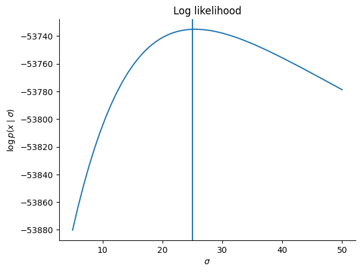

We could also do gradient-based optimization of the log likelihood function by using `jax`'s automatic differentiation tools.

```python
grad(ll)(28.)
```

grad(ll)(28.)

```
Array(-0.71183217, dtype=float32, weak_type=True)
```

### Bayesian inference with NumPyro

In Bayesian inverse optimal control, we are interested in the posterior distribution of the model parameters given a trajectory

$$ p(\theta \mid \mathbf x_{1:T}) \propto p(\mathbf x_{1:T} \mid \theta) \, p(\theta). $$

To sample from this posterior distribution, we will use `numpyro`, a probabilistic programming package powered by `jax`. For every random variable in the model (in our case the parameters and the observed data), we need to call `numpyro.sample` to define a name and a distribution.

```python
def lqg_model(x):

    # priors
    action_variability = numpyro.sample("action_variability", dist.HalfCauchy(1.))
    action_cost = numpyro.sample("action_cost", dist.HalfCauchy(1.))
    sigma_target = numpyro.sample("sigma_target", dist.HalfCauchy(50.))
    sigma_cursor = numpyro.sample("sigma_cursor", dist.HalfCauchy(15.))

    # setup model
    model = BoundedActor(action_variability=action_variability,
                       action_cost=action_cost,
                       sigma_target=sigma_target,
                       sigma_cursor=sigma_cursor)

    # likelihood
    numpyro.sample("x", model.conditional_distribution(x),
                  obs=x[:, 1:])
```

def lqg_model(x): # priors action_variability = numpyro.sample("action_variability", dist.HalfCauchy(1.)) action_cost = numpyro.sample("action_cost", dist.HalfCauchy(1.)) sigma_target = numpyro.sample("sigma_target", dist.HalfCauchy(50.)) sigma_cursor = numpyro.sample("sigma_cursor", dist.HalfCauchy(15.)) # setup model model = BoundedActor(action_variability=action_variability, action_cost=action_cost, sigma_target=sigma_target, sigma_cursor=sigma_cursor) # likelihood numpyro.sample("x", model.conditional_distribution(x), obs=x[:, 1:])

```python
nuts_kernel = NUTS(lqg_model)

mcmc = MCMC(nuts_kernel, num_warmup=500, num_samples=1000)
mcmc.run(random.PRNGKey(0), x)
```

nuts_kernel = NUTS(lqg_model) mcmc = MCMC(nuts_kernel, num_warmup=500, num_samples=1000) mcmc.run(random.PRNGKey(0), x)

```python
inference_data = az.from_numpyro(mcmc)

az.plot_pair(inference_data, reference_values=true_params, kind="kde")

summary = az.summary(inference_data)
```

inference_data = az.from_numpyro(mcmc) az.plot_pair(inference_data, reference_values=true_params, kind="kde") summary = az.summary(inference_data)

```
arviz - WARNING - Shape validation failed: input_shape: (1, 1000), minimum_shape: (chains=2, draws=4)
```

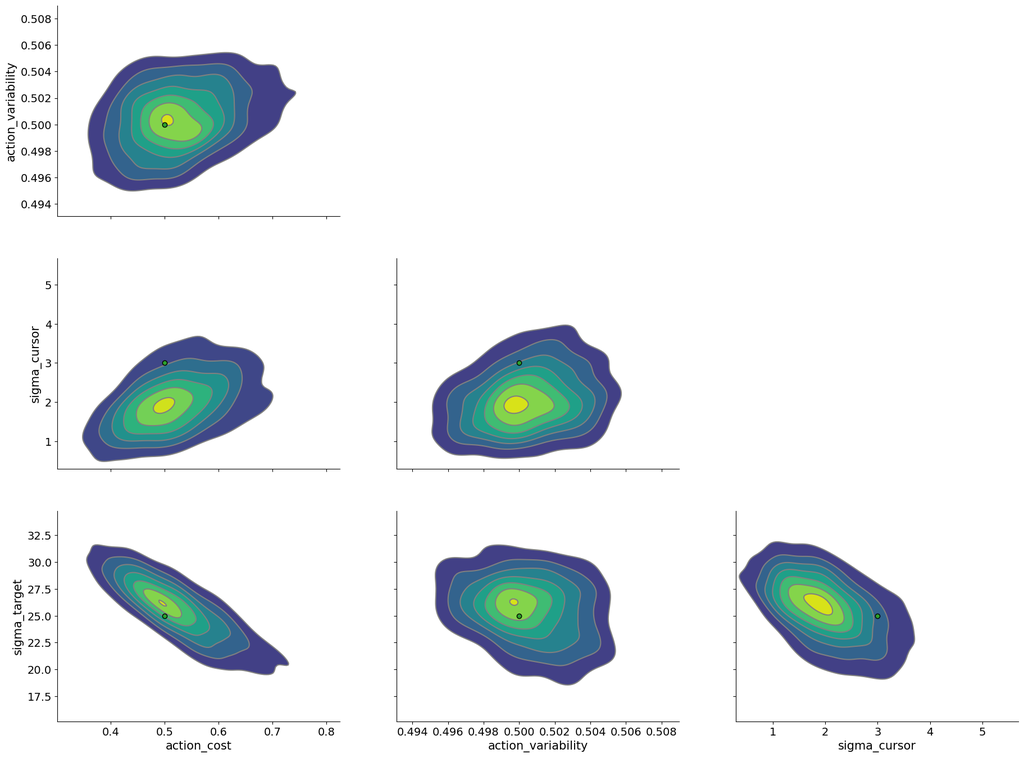

### Belief tracking

Once we have fit the model, we can use it to do belief tracking: We compute the probabilitiy distribution

$$ p(\hat{\mathbf x}_t | \mathbf x_{1:t}), $$

i.e. the researcher's uncertainty about the agent's belief.

```python
model = BoundedActor(**summary["mean"].to_dict())

x = model.simulate(random.PRNGKey(1), n=100)
```

model = BoundedActor(**summary["mean"].to_dict()) x = model.simulate(random.PRNGKey(1), n=100)

```python
d = model.belief_tracking_distribution(x)
belief_samples = d.sample(random.PRNGKey(0), sample_shape=(10,))
belief_mean = d.loc # get mean of belief distribution

f, ax = plt.subplots(1, 2)
ax[0].plot(jnp.arange(500) / 60, x[1, :, 0], label="target")
ax[0].plot(jnp.arange(1, 500) / 60, belief_mean[1, :, 0], label="belief about target", color="C2")
ax[0].plot(jnp.arange(1, 500) / 60, belief_mean[1, :, 1], label="belief about cursor", color="C1")

for i in range(10):
    ax[0].plot(jnp.arange(1, 500) / 60, belief_samples[i, 1, :, 0],
          color="C2", alpha=0.1, zorder=-1)
    ax[0].plot(jnp.arange(1, 500) / 60, belief_samples[i, 1, :, 1],
          color="C1", alpha=0.1, zorder=-1)
ax[0].set_ylim(-10, 50)
ax[0].set_title("Belief tracking")
ax[0].set_xlabel("Time [s]")
ax[0].set_ylabel("Position [arcmin]")
ax[0].legend(frameon=False)

# cross-correlograms with belief about cursor
lags, correls = xcorr(jnp.diff(belief_mean[..., 1], axis=1),
                      jnp.diff(x[..., 0], axis=1), maxlags=120)

ax[1].plot(lags / 60, correls.mean(axis=0), color="C1")

# cross-correlograms with belief about target
lags, correls = xcorr(jnp.diff(belief_mean[..., 0], axis=1),
                      jnp.diff(x[..., 0], axis=1), maxlags=120)

ax[1].plot(lags / 60, correls.mean(axis=0), color="C2")

ax[1].set_ylim(-.03, .12)
ax[1].set_title("Cross-correlogram")
ax[1].set_ylabel("Correlation")
ax[1].set_xlabel("Time lag [s]")

f.tight_layout()
```

d = model.belief_tracking_distribution(x) belief_samples = d.sample(random.PRNGKey(0), sample_shape=(10,)) belief_mean = d.loc # get mean of belief distribution f, ax = plt.subplots(1, 2) ax[0].plot(jnp.arange(500) / 60, x[1, :, 0], label="target") ax[0].plot(jnp.arange(1, 500) / 60, belief_mean[1, :, 0], label="belief about target", color="C2") ax[0].plot(jnp.arange(1, 500) / 60, belief_mean[1, :, 1], label="belief about cursor", color="C1") for i in range(10): ax[0].plot(jnp.arange(1, 500) / 60, belief_samples[i, 1, :, 0], color="C2", alpha=0.1, zorder=-1) ax[0].plot(jnp.arange(1, 500) / 60, belief_samples[i, 1, :, 1], color="C1", alpha=0.1, zorder=-1) ax[0].set_ylim(-10, 50) ax[0].set_title("Belief tracking") ax[0].set_xlabel("Time [s]") ax[0].set_ylabel("Position [arcmin]") ax[0].legend(frameon=False) # cross-correlograms with belief about cursor lags, correls = xcorr(jnp.diff(belief_mean[..., 1], axis=1), jnp.diff(x[..., 0], axis=1), maxlags=120) ax[1].plot(lags / 60, correls.mean(axis=0), color="C1") # cross-correlograms with belief about target lags, correls = xcorr(jnp.diff(belief_mean[..., 0], axis=1), jnp.diff(x[..., 0], axis=1), maxlags=120) ax[1].plot(lags / 60, correls.mean(axis=0), color="C2") ax[1].set_ylim(-.03, .12) ax[1].set_title("Cross-correlogram") ax[1].set_ylabel("Correlation") ax[1].set_xlabel("Time lag [s]") f.tight_layout()

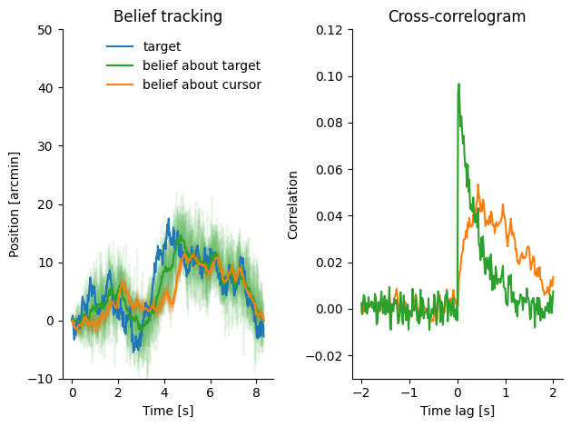